# Lab Assignment 5

# 2A

Null Hypothesis: The mean waiting time to mating in fed female crickets is equal to the mean waiting time to mating in starved female crickets (H_0: μ_1 = μ_2). Alternative Hypothesis: The mean waiting time to mating in fed female crickets is not equal to the mean waiting time to mating in starved female crickets (H_A: μ_1 =/= μ_2).

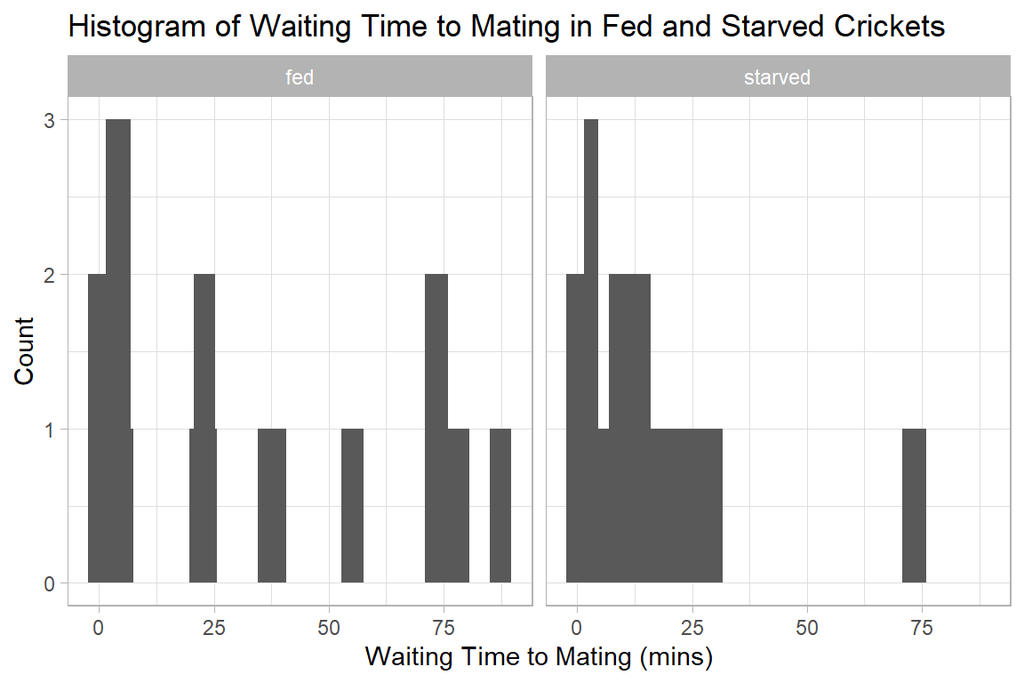

```r
#loading in cricket data
cricket_data <- read.csv("~/EEMB 146 Lab Files/Lab 5 Data/starving_cricket.csv")

# visualizing data --histogram
ggplot(cricket_data, aes(x = time_to_mating)) +
  geom_histogram() +
  facet_wrap(~ feeding) +  #separates histogram based on a certain grouping
  theme_light() +
  stat_bin(bins = 20) +
  labs(x = "Waiting Time to Mating (mins)", y = "Count") +
  ggtitle("Histogram of Waiting Time to Mating in Fed and Starved Crickets")
```

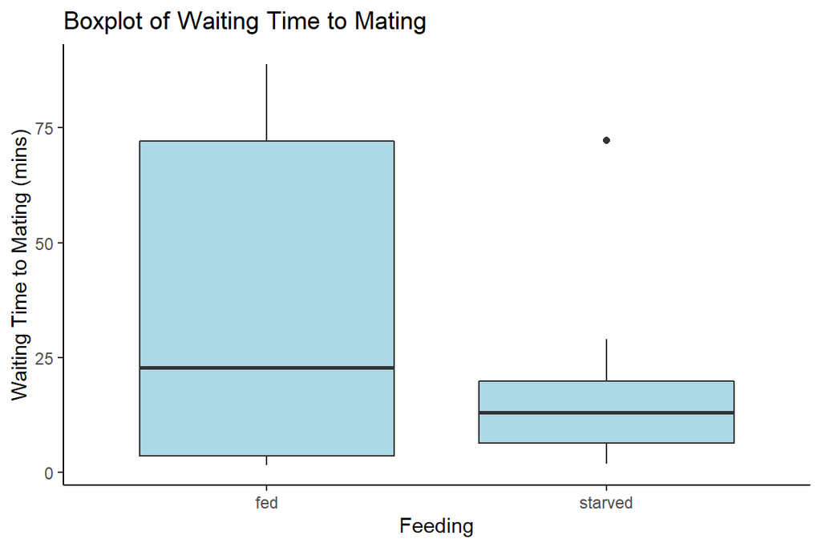

```r
#boxplot
ggplot(cricket_data, aes(x = feeding, y = time_to_mating)) +
  geom_boxplot(fill = "lightblue") +
  theme_classic() +
  labs(x = "Feeding", y = "Waiting Time to Mating (mins)") +
  ggtitle("Boxplot of Waiting Time to Mating ")
```

# 2B and Observations

The histogram for both fed and starved plots do not look normal and shows a large spread as well as a slight right skew. This is also prevalent in the boxplot in which fed cricket data has a larger spread compared to that of the starved cricket data. Fed cricket data has a higher median compared to that of the starved cricket data. Only the starved data has an outlier at around 75 mins.

```r
# first will be testing normality of non-transformed data
fit_cricket <- lm(time_to_mating~feeding, data = cricket_data)
res_cricket = fit_cricket$residuals

shapiro.test(res_cricket) # p-value = 0.03308
```

```
##
##  Shapiro-Wilk normality test
##
## data:  res_cricket
## W = 0.90871, p-value = 0.03308
```

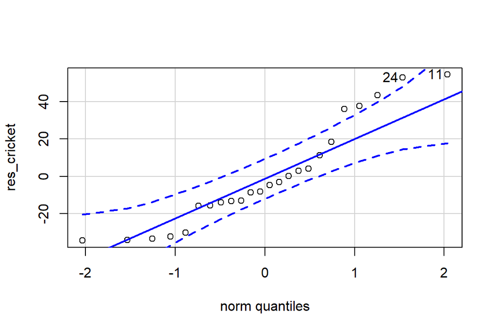

```
## [1] 11 24
```

```r
qqPlot(res_cricket)
```

# 2C

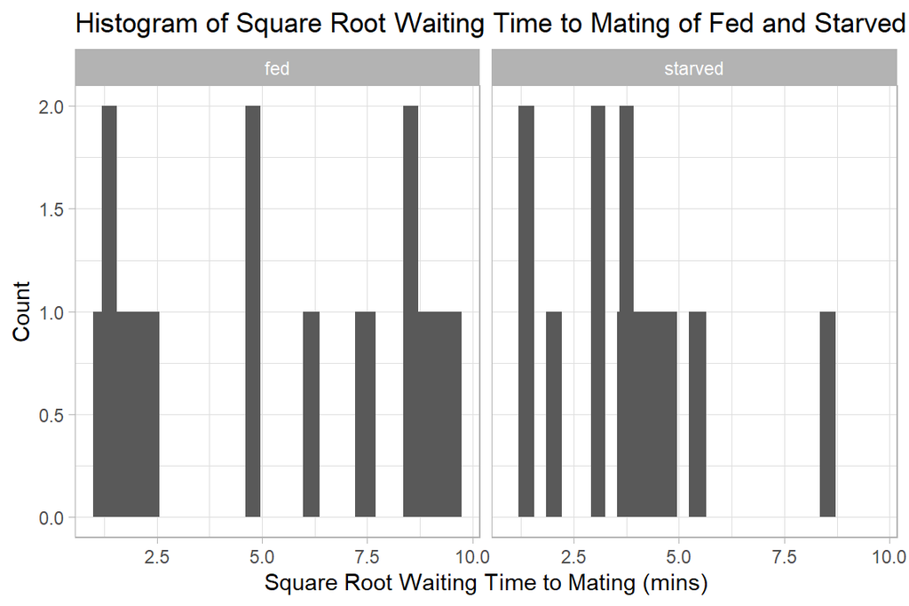

```r
# sqrt transform cricket data
cricket_data$sqrt_time_to_mating <- sqrt(cricket_data$time_to_mating)

#visualize sqrt data
ggplot(cricket_data, aes(x = sqrt_time_to_mating)) +
  geom_histogram() +
  facet_wrap(~ feeding) +
  theme_light() +
  stat_bin(bins = 25) +
  labs(x = "Square Root Waiting Time to Mating (mins)", y = "Count") +
  ggtitle("Histogram of Square Root Waiting Time to Mating of Fed and Starved Crickets")
```

```r
#test normality of sqrt data
fit_sqrt_cricket <- lm(sqrt_time_to_mating~feeding, data = cricket_data)
res_sqrt_cricket = fit_sqrt_cricket$residuals

shapiro.test(res_sqrt_cricket) # p-value = 0.2968
```

```
##
##  Shapiro-Wilk normality test
##
## data:  res_sqrt_cricket
## W = 0.95184, p-value = 0.2968
```

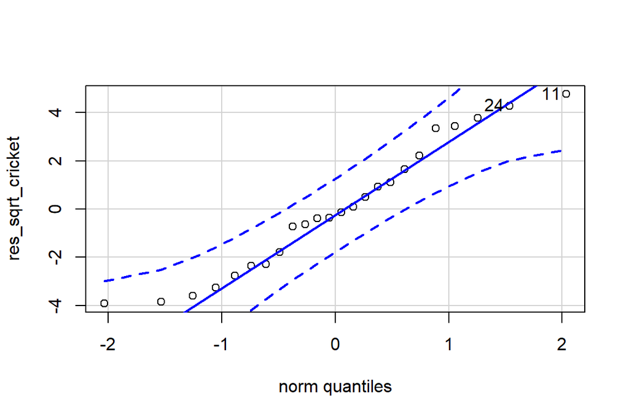

```
## [1] 11 24
```

```r
qqPlot(res_sqrt_cricket)
```

# 2D

I tested out two different transformations on the data, log transformation (not shown) and square root transformation (sqrt). The sqrt transformed data was normal so I kept it instead of the log transformed data.

A Shapiro-Wilk test was done on the residuals of sqrt_time_to_mating vs. feeding. The null hypothesis (H_0) is that the transformed residual data is normal and the alternative hypothesis (H_A) is that the transformed residual data is not normal. Because the residual data got a p-value of 0.2968, which is bigger than p = 0.05, I fail to reject the hypothesis and can confidently say that the transformed residual data is normal. In addition, in the qqPlot, most of the transformed datapoints were within the confidence bands which is also an indication of normality.

```r
# levene test for sqrt cricket data
leveneTest(cricket_data$sqrt_time_to_mating, cricket_data$feeding) #p-value = 0.03302
```

```
## Levene's Test for Homogeneity of Variance (center = median)
##       Df F value  Pr(>F)
## group  1  5.1746 0.03302 *
##       22
## ---
## Signif. codes:  0 '***' 0.001 '**' 0.01 '*' 0.05 '.' 0.1 ' ' 1
```

# 2E

A levene test was done on the transformed cricket data in which the null hypothesis (H_0) is that the sqrt variances are equal and the alternative hypothesis (H_A) is that the sqrt variances are not equal. This p-value of the levene test tells me that the chance of getting an F-score of 5.1746 by chance is 3.3%/ Because the test produced a p-value of 0.03302, which is less than 0.05, I reject the null hypothesis that the sqrt variances are equal.

Since the sqrt variances are not equal I decided to do a Welch’s t-test on the transformed data. I’m choosing to use this instead of the Mann-Whitney U-Test because the Welch’s t-test is a parametric test and therefore is more powerful than the Mann-Whitney U-test.

```r
# two sample t-test
feeding_fed <- subset(cricket_data, feeding == "fed")
feeding_starved <- subset(cricket_data, feeding == "starved")
t.test(feeding_fed$sqrt_time_to_mating, feeding_starved$sqrt_time_to_mating, var.equal = FALSE) # p-value = 0.2055
```

```
##
##  Welch Two Sample t-test
##
## data:  feeding_fed$sqrt_time_to_mating and feeding_starved$sqrt_time_to_mating
## t = 1.3075, df = 20.568, p-value = 0.2055
## alternative hypothesis: true difference in means is not equal to 0
## 95 percent confidence interval:
##  -0.837051  3.662255
## sample estimates:
## mean of x mean of y
##  5.148254  3.735652
```

# 2F

Because I conducted a Welch’s t-test on the transformed data the null and alternative hypotheses are the following:

Null Hypothesis: The sqrt waiting time to mating in fed female crickets is equal to the sqrt waiting time to mating in starved female crickets (H_0: μ_1 = μ_2). Alternative Hypothesis: The sqrt waiting time to mating in fed female crickets is not equal to the sqrt waiting time to mating in starved female crickets (H_A: μ_1 =/= μ_2).

The test statistic is 1.3075 and the p-value is 0.2055, which is much larger than p = 0.05. Therefore I fail to reject the null hypothesis and say there is no difference between the sqrt time to mating between fed and starved crickets. There is a 20.55% that any difference between sqrt time to mating is due to random chance. Based on my results, it seems that it doesn’t matter whether female crickets are starved or fed and that they will mate whether hungry or not. Perhaps female crickets can detect the male’s fitness through consumption of their wings which is useful deciding on a mate that will produce the best offsprings.